# Reproducible Research: Peer Assessment 1

Jona N

Jan 13th, 2015

## Loading and preprocessing the data

. Unzip and loading the data

```r
if(!file.exists("activity.csv")) unzip("activity.zip")
dataset <- read.csv("activity.csv")
summary(dataset)
```

```
##      steps               date          interval
##  Min.   :  0.0   2012-10-01:  288   Min.   :   0
##  1st Qu.:  0.0   2012-10-02:  288   1st Qu.: 589
##  Median :  0.0   2012-10-03:  288   Median :1178
##  Mean   : 37.4   2012-10-04:  288   Mean   :1178
##  3rd Qu.: 12.0   2012-10-05:  288   3rd Qu.:1766
##  Max.   :806.0   2012-10-06:  288   Max.   :2355
##  NA's   :2304    (Other)   :15840
```

```r
head(dataset)
```

```
##   steps       date interval
## 1    NA 2012-10-01        0
## 2    NA 2012-10-01        5
## 3    NA 2012-10-01       10
## 4    NA 2012-10-01       15
## 5    NA 2012-10-01       20
## 6    NA 2012-10-01       25
```

## What is mean total number of steps taken per day?

### In this part we’re ignoring the missing values in the dataset

### 1. Make a histogram of the total number of steps taken each day

. computing the number of steps taken each day

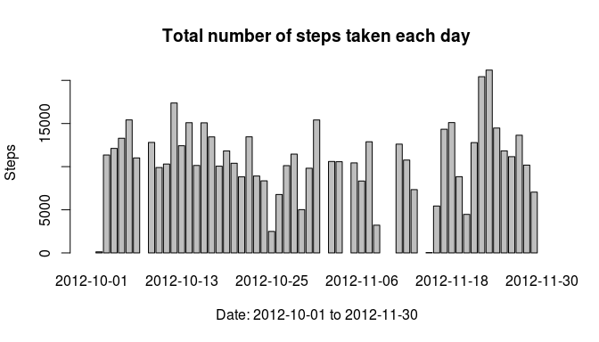

```r
sumData<-with(dataset, tapply(steps, date, sum))
barplot(sumData, main="Total number of steps taken each day",
        xlab="Date: 2012-10-01 to 2012-11-30", ylab="Steps")
```

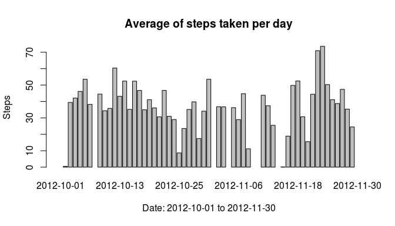

```r
meanData<-with(dataset, tapply(steps, date, mean))
barplot(meanData, main="Average of steps taken per day",
        xlab="Date: 2012-10-01 to 2012-11-30", ylab="Steps")
```

```r
mean(meanData, na.rm=TRUE)
```

```
## [1] 37.38
```

```r
median(meanData, na.rm=TRUE)
```

```
## [1] 37.38
```

## What is the average daily activity pattern?

### 1. Make a time series plot (i.e. type = “l”) of the 5-minute interval (x-axis) and the average number of steps taken, averaged across all days (y-axis)

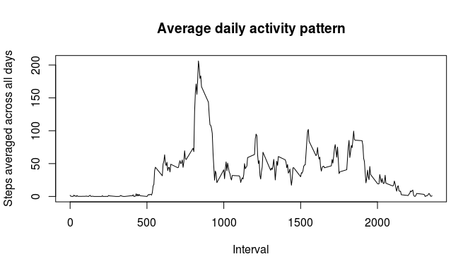

```r
with(aggregate(steps ~ interval, data=dataset, mean, na.rm = T),
     plot(interval, steps, type="l", main="Average daily activity pattern",
     xlab="Interval", ylab="Steps averaged across all days"))
```

```r
max(aggregate(steps ~ interval, data=dataset, mean, na.rm = T)$steps)
```

```
## [1] 206.2
```

## Imputing missing values

### 1. Calculate and report the total number of missing values in the dataset (i.e. the total number of rows with NAs)

```r
sum(is.na(dataset$steps))
```

```
## [1] 2304
```

### 2. Devise a strategy for filling in all of the missing values in the dataset. The strategy does not need to be sophisticated. For example, you could use the mean/median for that day, or the mean for that 5-minute interval, etc.

. Computing the mean for that 5-minute interval

```r
library("plyr")
tidyData<-dd<-dataset
pp <- ddply(dd, .(interval), summarize, means = mean(steps, na.rm=TRUE))
```

### 3. Create a new dataset that is equal to the original dataset but with the missing data filled in.

. Filling all the missing values of the dataset in new dataset

```r
l<-which(is.na(dataset))
tidyData$steps[l]<-pp$means[pp$interval %in% dataset$interval[l]]
sum(is.na(tidyData$steps))
```

```
## [1] 0
```

```r
head(tidyData)
```

```
##     steps       date interval
## 1 1.71698 2012-10-01        0
## 2 0.33962 2012-10-01        5
## 3 0.13208 2012-10-01       10
## 4 0.15094 2012-10-01       15
## 5 0.07547 2012-10-01       20
## 6 2.09434 2012-10-01       25
```

. computing the number of steps taken each day

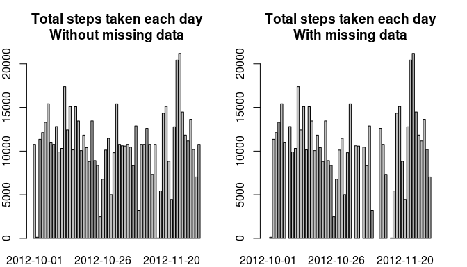

```r
par(mfrow=c(1,2), mar=c(2,2,4,2))

sumDataTidy<-with(tidyData, tapply(steps, date, sum))
barplot(sumDataTidy, main="Total steps taken each day\nWithout missing data",
        xlab="Date: 2012-10-01 to 2012-11-30", ylab="Steps")

sumData<-with(dataset, tapply(steps, date, sum))
barplot(sumData, main="Total steps taken each day\nWith missing data",
        xlab="Date: 2012-10-01 to 2012-11-30", ylab="Steps")
```

. computing the mean of steps taken each day

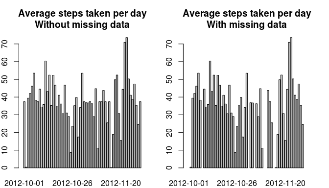

```r
par(mfrow=c(1,2), mar=c(2,2,4,2))

meanDataTidy<-with(tidyData, tapply(steps, date, mean))
barplot(meanDataTidy, main="Average steps taken per day\nWithout missing data",
        xlab="Date: 2012-10-01 to 2012-11-30", ylab="Steps")

meanData<-with(dataset, tapply(steps, date, mean))
barplot(meanData, main="Average steps taken per day\nWith missing data",
        xlab="Date: 2012-10-01 to 2012-11-30", ylab="Steps")
```

```r
mean(meanDataTidy, na.rm=TRUE)
```

```
## [1] 37.38
```

```r
median(meanDataTidy, na.rm=TRUE)
```

```
## [1] 37.38
```

## Are there differences in activity patterns between weekdays and weekends?

### 1. Create a new factor variable in the dataset with two levels – “weekday” and “weekend” indicating whether a given date is a weekday or weekend day.

```r
tidyData$week<-as.character(weekdays(as.Date(tidyData$date)))
tidyData$week[!tidyData$week %in% c("sábado","domingo")]<-"weekday"
tidyData$week[tidyData$week %in% c("sábado","domingo")]<-"weekend"
tidyData$week<-factor(tidyData$week, levels = c("weekday", "weekend"))
table(tidyData$week)
```

```
##
## weekday weekend
##   12960    4608
```

```r
str(tidyData)
```

```
## 'data.frame':    17568 obs. of  4 variables:
##  $ steps   : num  1.717 0.3396 0.1321 0.1509 0.0755 ...
##  $ date    : Factor w/ 61 levels "2012-10-01","2012-10-02",..: 1 1 1 1 1 1 1 1 1 1 ...
##  $ interval: int  0 5 10 15 20 25 30 35 40 45 ...
##  $ week    : Factor w/ 2 levels "weekday","weekend": 1 1 1 1 1 1 1 1 1 1 ...
```

### 2. Make a panel plot containing a time series plot (i.e. type = “l”) of the 5-minute interval (x-axis) and the average number of steps taken, averaged across all weekday days or weekend days (y-axis). See the README file in the GitHub repository to see an example of what this plot should look like using simulated data.

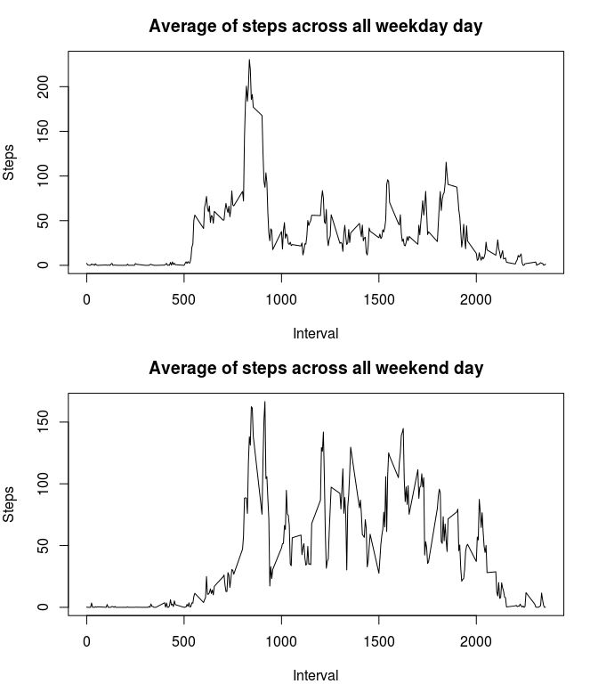

```r
par(mfrow=c(2,1), mar=c(4,4,3,2))
with(subset(aggregate(steps ~ interval + week, data = tidyData, mean),week=="weekday"), plot(interval, steps, type="l", main="Average of steps across all weekday day", xlab="Interval", ylab="Steps"))
with(subset(aggregate(steps ~ interval + week, data = tidyData, mean),week=="weekend"), plot(interval, steps, type="l", main="Average of steps across all weekend day", xlab="Interval", ylab="Steps"))
```